# Evaluación de Impacto del Programa Prospera

Equipo 6: Adrián, Alexa, Jorge, Miguel, Carlos

28/5/2021

# Estrategia de Focalización - Programa Prospera

*Objetivo:* El presente documento realiza un análisis de impacto del programa PROSPERA utilizando herramientas de aprendizaje estadistico para identificar los hogares donde el plan fue exitoso. Con esto en mente, nuestra recomendación es que, en caso de un recorte presupuestario, focalizar el programa empezando repartir los apoyos a hogares que tienen individuos con una edad alta (aproximadamente de 40 años), que tienen un gasto alimenticio menor a los $3500 pesos, y que tengan un número alto de hijos o dependientes económicos.

## Introducción

PROSPERA fue un programa de la Secretaría de Desarrollo Social de 2014 a 2018, el cual otorgó recursos a casi 7 millones de familias mexicanas para fortalecer su alimentación, salud y educación; asimismo tenía la intención de vincular a las personas beneficiarias con proyectos productivos, opciones laborales y servicios financieros. El programa contaba con el respaldo y la experiencia de otros dos planes implementados por el gobierno mexicano: El Programa de Educación, Salud y Alimentación (Progresa) que inició en agosto de 1997 y cubrió hasta 2.4 millones de hogares para 2002 y el programa Oportunidades que ocupó el lugar de Progresa en 2002 y terminó operaciones en 2013 aumentando su cobertura a los 32 estados del país y 4.2 millones de hogares atendidos.

El 4 de septiembre de 2014, Oportunidades se transformó en “PROSPERA - Programa de Inclusión Social” con la intención de articular y coordinar la oferta institucional de programas y acciones de política social dirigidas a la población en situación de pobreza. En su operación, este programa consistía en diversos apoyos económicos directos condicionados (conocidos en inglés como *conditional cash transfers*) los cuales eran otorgados generalmente a las madres de familia por medio de tarjetas bancarias. Para que un hogar pudiera ser beneficiario del programa, previamente se identificaban a aquellos que se encontraban en situación de vulnerabilidad, por medio de una encuesta de características socioeconómicas y demográficas, llamada oficialmente Cuestionario Único de Información Socieconómica (CUIS) ejecutado y diseñado por la Secretaría de Desarrollo Social (SEDESOL). Idealmente, la población objetivo consitía en aquellos hogares con un ingreso per cápita menor a la linea de bienestar mínimo (LBM), y aquellos que ya estaban dentro del programa pero permanecían abajo de la Línea de Verificaciones Permamentes de Condiciones Socioeconómicas (LVPCS) siempre y cuando tuvieran un integrante menor de 22 años asistiendo a la escuela.

El programa contaba con metas, llamados en sus proyectos “ámbitos de beneficio”, muy amplias, las cuales abarcaban: a) Alimentación, b) Educación, c) Salud, d) Inclusión laboral, e) Inclusión Productiva, f) Inclusión Financiera, g) Inclusión Social, h) Participación social y i) Derecho de Audiencia. Los apoyos se ramificaban en al menos 5 tipos distintos: 1) Apoyo Alimentario, 2) Apoyo alimentario complementario, 3) Apoyo para Becas Educativas, 4) Apoyo para útiles escolares y 5) Apoyo para adultos mayores. Estos eran otorgados por medio de transferencias monetarias bimestrales (depósito a la tarjeta) o en apoyos en especie correspondientes a los componentes de alimentación, salud y educación, los cuales usualmente consistían en suplementos alimenticios y útiles escolares. Desde sus antecesores, Progresa y Oportunidades, en salud y educación a los beneficiarios se les exige el cumplimiento de corresponsabilidades incluyendo asistir a consultas y talleres programados e inscribirse y asisistir a la escuela. En el año de 2014, Prospera atendió a 6,129,125 de familias y su presupuesto asignado para el ejercicio de 2015 rozó los 75 millones de pesos equivalentes al 0.4% del PIB. A partir del año fiscal de 2019, Prospera fue sustituido por el Programa de Becas para el Bienestar Benito Juárez con distintas reglas de operación y objetivos.

## Evaluación de Impacto

Para el presente análisis buscamos focalizar los recursos a aquellos hogares en los cuales el programa Prospera haya tenido más éxito. Para evaluar a la población objetivo utilizamos los datos de la Encuesta Nacional de Ingresos y Gastos (ENIGH) del año 2018. Esta encuesta, realizada de manera bianual por el INEGI, registra de manera detallada los montos, procedencia y distribución de los ingresos en los hogares. En ella, por medio de diversas bases de datos, se identifica lo que los mexicanos perciben como salario, prestaciones, transferencias y su pertenencia a diversos programas de apoyo y cobertura gubernamental. Adicionalmente, también se hacen preguntas de sus condiciones de vivienda, activos con los que cuenta y situaciones de carencia y vulnerabilidad sanitaria, económica o física.

En nuestro análisis definimos tres metas sobre las cuales evaluamos la relevancia de Prospera:

1. Si en alguna ocasión el hogar se preocupó porque faltara comida.
2. La probabilidad de que los miembros del hogar tuvieran un empleo informal.
3. La probabilidad de que los integrantes terminaran la secundaria.

Estos tres puntos son relevantes puesto que forman parte de los objetivos generales que buscaba corregir Prospera, particularmente: a) Alimentación, b) Inclusión Laboral y c) Educación.

## Preparación de la Base

Una vez que identificamos las tres variables dependientes (objetivo) sobre las cuales evaluamos el éxito (o fracaso) de PROSPERA, es necesario extraer la información de cada uno de los individuos del estudio. La construcción de la matriz de características está lejos de ser trivial dado que requiere de todo un trabajo de limpieza en la base. Esto es particularmente problemático en nuestro contexto dadas las particularidades de la ENIGH. Tras bambalinas, el paso previo a la estimación de los modelos consistió en unir al menos 5 bases distintas: que lograran explicar algo de las personas (i.e. que fueran relevantes para el estudio) y que quedaran homologadas para poder ser utilizadas por el algoritmo.

Las preguntas de cada una de las bases (o cuestionarios según el INEGI) capturan diversas dimensiones que definen a los individuos que participan en la encuesta. Por ejemplo, en el caso de vivienda extraemos información sobre las características físicas de su hogar como el material de los pisos, techos, número de cuartos, acceso a servicios básicos, tenencia de inmuebles, entre otros. En el módulo del hogar identificamos los activos a los que tiene acceso (electrodomésticos, servicio de telefonía, internet, etc.) pero también preguntas de acceso alimentario tanto del número de comidas diarias como la calidad de los mismos. En el cuestionario de población extraemos información demográfica, si existe algún problema de discapacidad, nivel educativo, afiliaciones de seguridad social, actividades de su vida cotidiana y asignación de su tiempo. Por último, en los módulos de “ingresos” y “trabajos” extraemos todo lo relativo a su posición en el mercado laboral, salarios, prestaciones, transferencias, créditos, horas trabajadas y acceso al sistema financiero.

Con la información de los hogares extraida de la ENIGH, podemos identificar la proporción de mexicanos que sufren de estas carencias, quiénes de ellos son beneficiarios de PROSPERA y quiénes pertenecen a un grupo de situación vulnerable (población femenina e indígena).

## Estadísticas Descriptivas

Tomamos en cuenta diversas variables de interés para identificar su relación con el programa Prospera. En todos los casos, empleamos el factor de expansión que venía incluido en la base de datos a nivel población, para conocer tanto el número de personas como el porcentaje a nivel nacional que sufre alguna de las carencias de interés o que es beneficiario del programa.

En primer lugar, nos enfocamos en la carencia alimentaria. En la ENIGH se le pregunta a los individuos si se vieron en la preocupación de que la comida se acabara alguna vez por falta de dinero.

```r
#Alguna vez por falta de dinero o recursos, se vio en la preocupación que la comida se acabara.
#1 es Sí
#2 es no

kable(base_alim1, align = c("c", "c", "c"),
      caption="Alguna vez por falta de dinero o recursos, se vio en la preocupación que la comida se acabara.", digits=3,
      col.names = linebreak(c("Respuesta", "Población", "Porcentaje")))%>%
  kable_classic(full_width = F, html_font = "Cambria") %>%
  footnote(general = "Elaboración propia con datos de ENIGH (2018).",threeparttable = T, footnote_as_chunk = T) %>%
  row_spec(0, bold = T)
```

Alguna vez por falta de dinero o recursos, se vio en la preocupación que la comida se acabara.

| Respuesta | Población | Porcentaje |
| --- | --- | --- |
| Sí | 162398108 | 0.423 |
| No | 221946606 | 0.577 |

Note: Elaboración propia con datos de ENIGH (2018).

Tomando esta pregunta como proxy de la carencia alimentaria, notamos que en México, un total de 162398108 de personas tienen esta carencia, es decir un %42.25 de la población.

Por otro lado, estamos interesados en la relación entre pertenecer al programa y laborar en el sector informal. Para identificar si un individuo labora en la informalidad, no basamos en el paper “Finance and Employment Formalization: Evidence from Mexico’s Income-Expenditure Surveys”, de Bazdresch y Werner (2011). Estos autores identificaron a los integrantes de la informalidad por medio de algunas características particulares: - Si no existe un contrato laboral por escrito con el trabajador. - El trabajador no recibe pago y trabaja en un negocio del hogar, o es un trabajador(a) sin pago en un negocio que no es del hogar. - El trabajador no percibe prestaciones, como incapacidad médica, aguinaldo, vacaciones, reparto de utilidades, crédito de vivienda, guarderías, cuidados maternos o paternos, SAR o AFORE, seguro de vida, préstamos, prima vacacional, apoyos educativos, servicio de comedor, FONACOT, despensas, ayuda a pago de servicios, pensión de invalidez, pensión por fallecimiento u otras prestaciones.

Para propósitos de nuestro ejercicio, los informales serán aquellos que cumplan con al menos una de estas condiciones.

```r
#Informalidad se va a sacar a través de 5 distintas preguntas (ver paper Finance and Employment Formalization: Evidence
#from Mexico's Income-Expenditure Surveys)

#1) Contrato - ¿Existe un contrato laboral por escrito con el trabajador?
#1 es Sí
#2 es no
base %>%
  group_by(contrato)%>%
  summarise(total=n())%>%
  mutate(porcentaje=total/sum(total),
         Contrato=ifelse(contrato==1,"Sí",ifelse(contrato==2,"No","NA")))%>%
  dplyr::select(Contrato,total,porcentaje) %>%
kable(align = c("c", "c", "c"), caption="Existencia de un contrato laboral por escrito.", digits=3, col.names = linebreak(c("Contrato", "Total", "Porcentaje")))%>%
  kable_classic(full_width = F, html_font = "Cambria") %>%
  footnote(general = "Elaboración propia con datos de ENIGH (2018).",threeparttable = T, footnote_as_chunk = T) %>%
  row_spec(0, bold = T)
```

Existencia de un contrato laboral por escrito.

| Contrato | Total | Porcentaje |
| --- | --- | --- |
| Sí | 419278 | 0.513 |
| No | 283807 | 0.347 |
| NA | 114134 | 0.140 |

Note: Elaboración propia con datos de ENIGH (2018).

```r
#2) Como le pagaron? (#9)
#1 recibe pago
#2 trabajador sin pago en un negocio del hogar
#3 trabajador sin pago en un negocio que no es del hogar
base %>%
  mutate(Pago=ifelse(pago==1,"Sí",ifelse(pago==2|3,"No","NA")))%>%
  group_by(Pago)%>%
  summarise(total=sum(factor,na.rm=T))%>%
  mutate(porcentaje=total/sum(total))%>%
  dplyr::select(Pago,total,porcentaje) %>%
kable(align = c("c", "c", "c"), caption="Cómo le pagaron: ¿Recibe un pago o no?",digits=3, col.names = linebreak(c("Pago", "Total", "Porcentaje")))%>%
  kable_classic(full_width = F, html_font = "Cambria") %>%
  footnote(general = "Las opciones de respuesta son: a) Sin Pago en un negocio del hogar ó b) Sin pago en un negocio fuera del hogar. Elaboración propia con datos de ENIGH (2018).",threeparttable = T, footnote_as_chunk = T) %>%
  row_spec(0, bold = T)
```

Cómo le pagaron: ¿Recibe un pago o no?

| Pago | Total | Porcentaje |
| --- | --- | --- |
| No | 4207287 | 0.011 |
| Sí | 344342455 | 0.896 |
| NA | 35794972 | 0.093 |

Note: Las opciones de respuesta son: a) Sin Pago en un negocio del hogar ó b) Sin pago en un negocio fuera del hogar. Elaboración propia con datos de ENIGH (2018).

```r
#3) ¿Recibe prestaciones?
 kable(base_prestaciones,  align = c("c", "c", "c"), caption="En el trabajo que tuvo, ¿le dieron alguna prestación?", digits=3, col.names = linebreak(c("Prestaciones", "Total", "Porcentaje")))%>%
  kable_classic(full_width = F, html_font = "Cambria")%>%
  footnote("Prestaciones: Incapacidad médica, aguinaldo, vacaciones, reparto de utilidades, crédito de vivienda, guarderías, cuidados maternos o paternos, SAR o AFORE, seguro de vida, préstamos, prima vacacional, apoyos educativos, servicio de comedor, FONACOT, despensas, ayuda a pago de servicios, pensión de invalidez, pensión por fallecimiento u otras prestaciones.",threeparttable = T, footnote_as_chunk = T) %>%
  row_spec(0, bold = T)
```

En el trabajo que tuvo, ¿le dieron alguna prestación?

| Prestaciones | Total | Porcentaje |
| --- | --- | --- |
| No | 129761170 | 0.338 |
| Sí | 254027649 | 0.662 |

Note: Prestaciones: Incapacidad médica, aguinaldo, vacaciones, reparto de utilidades, crédito de vivienda, guarderías, cuidados maternos o paternos, SAR o AFORE, seguro de vida, préstamos, prima vacacional, apoyos educativos, servicio de comedor, FONACOT, despensas, ayuda a pago de servicios, pensión de invalidez, pensión por fallecimiento u otras prestaciones.

```r
# Con estas condiciones realizamos la categorización de informales.
base_2<-base %>%
  mutate(prestaciones=ifelse(pres_1==1|pres_2==2|pres_3==3|pres_4==4|pres_5==5
                             |pres_6==6|pres_7==7|pres_8==8|pres_9==9|pres_10==10
                             |pres_11==11|pres_12==12|pres_13==13|pres_14==14
                             |pres_15==15|pres_16==16|pres_17==17|pres_18==18
                             |pres_19==19,1,2))%>%
  dplyr::select(prestaciones,factor,contrato,pago, edad)%>%
  mutate_all(~replace(., is.na(.), 0))%>%
  mutate(informal=ifelse(contrato==2|pago==2|pago==3|prestaciones!=1,1,0))

base_informalidad<-base_2 %>%
  filter(edad>12) %>%
  group_by(informal)%>%
  summarise(total=sum(factor,na.rm=T))%>%
  mutate(porcentaje=total/sum(total),
         informal=ifelse(informal==1,"Sí",ifelse(informal==0,"No","NA")))%>%
  dplyr::select(informal,total,porcentaje)

kable(base_informalidad, align = c("c", "c", "c"), caption="¿El individuo trabaja en el sector informal?",digits=3, col.names = linebreak(c("Pago", "Total", "Porcentaje"))) %>%
  kable_classic(full_width = F, html_font = "Cambria") %>%
  footnote(general = "Elaboración propia con cálculos a partir de ENIGH (2018).",threeparttable = T, footnote_as_chunk = T) %>%
  row_spec(0, bold = T)
```

¿El individuo trabaja en el sector informal?

| Pago | Total | Porcentaje |
| --- | --- | --- |
| No | 207610040 | 0.541 |
| Sí | 176178779 | 0.459 |

Note: Elaboración propia con cálculos a partir de ENIGH (2018).

En estas preguntas, encontramos que 283807 personas respondieron que trabajaban sin un contrato por escrito. También, 4207287 individuos trabajaban sin alguna remuneración, y sólo 254027649 contestaron que recibían alguna prestación .

Considerando todo lo anterior, encontramos que 176178779 individuos pertenecerían a la informalidad, el % 45.9 de las personas con más de 12 años en la muestra.

Ahora estimamos la proporción de personas con un nivel educativo igual o mayor a la secundaria. Esto será útil para revisar si quienes reciben el programa Prospera ven alguna mejora en la carencia educativa.

```r
#La probabilidad de los integrantes terminaran la secundaria
#Nivel aprob
#3 o más es educación mayor o igual a secundaria

kable(base_educacion, align = c("c", "c", "c"), caption="Integrantes que terminaron la secundaria.",digits=3, col.names = linebreak(c("Pago", "Total", "Porcentaje")))%>%
  kable_classic(full_width = F, html_font = "Cambria") %>%
  footnote(general = "Elaboración propia con datos de ENIGH (2018).",threeparttable = T, footnote_as_chunk = T) %>%
  row_spec(0, bold = T)
```

Integrantes que terminaron la secundaria.

| Pago | Total | Porcentaje |
| --- | --- | --- |
| Sí | 317785761 | 0.827 |
| No | 66558953 | 0.173 |

Note: Elaboración propia con datos de ENIGH (2018).

En México, el 17.3175149% de la población respondió que tiene un nivel educativo menor a secundaria. Es un porcentaje relativamente elevado, pero suena razonable para el país.

Posteriormente procedimos a identificar a los beneficiarios del programa Prospera. Para esto, empleamos las siguientes variables: i) si el programa Prospera le otorgó una beca escolar al individuo, ii) si IMSS/Prospera le proporciona servicios de salud al entrevistado, iii) si el individuo frecuenta Prospera para recibir atención médica, iv) si Prospera es la primera o segunda institución en la que el individuo atiende su salud y v) si el individuo recibe ingresos por transferencias de Prospera. Definimos a los beneficiarios del programa, como aquellos individuos que obtienen cualquiera de estos beneficios de Prospera, ya que para recibirlos deben estar inscritos en el padrón del programa.

```r
#Identificación de gente en el programa prospera

base %>%
  mutate(Prospera=ifelse(otorg_b==1|inst_5==5|servmed_4==4|inst_1==12|inst_2==12|ing_prospera>0,1,2))%>%
  dplyr::select(Prospera,factor)%>%
  mutate_all(~replace(., is.na(.), 0))%>%
  group_by(Prospera)%>%
  summarise(total=sum(factor,na.rm=T))%>%
  mutate(porcentaje=total/sum(total),
         Prospera=ifelse(Prospera==1,"Sí","No"))%>%
  dplyr::select(Prospera,total,porcentaje) %>%
kable(align = c("c", "c", "c"), caption="Individuos en el programa PROSPERA",digits=3, col.names = linebreak(c("Prospera", "Total", "Porcentaje")))%>%
  kable_classic(full_width = F, html_font = "Cambria") %>%
  footnote(general = "Elaboración propia con datos de ENIGH (2018).",threeparttable = T, footnote_as_chunk = T) %>%
  row_spec(0, bold = T)
```

Individuos en el programa PROSPERA

| Prospera | Total | Porcentaje |
| --- | --- | --- |
| No | 111626988 | 0.892 |
| Sí | 13562630 | 0.108 |

Note: Elaboración propia con datos de ENIGH (2018).

Con esta información, pudimos identificar que 10.8336699% de la población obtiene algún beneficio del programa, ya sea de forma directa o a través de alguna relación familiar. Esto es, un total de 13562630 de personas tienen acceso a Prospera.

Dado que nos interesa analizar la relación del programa con las carencias anteriormente establecidas (informalidad, alimentación y educación), nos disponemos a analizar el número de personas que tienen distinto número de carencias y cuántas tienen acceso al programa prospera.

```r
base<-base%>%
  mutate(preocupacion_comida=ifelse(acc_alim1==1,1,ifelse(acc_alim1==2,0,"NA")))
base_2<-base%>%
  mutate(prestaciones=ifelse(pres_1==1|pres_2==2|pres_3==3|pres_4==4|pres_5==5
                             |pres_6==6|pres_7==7|pres_8==8|pres_9==9|pres_10==10
                             |pres_11==11|pres_12==12|pres_13==13|pres_14==14
                             |pres_15==15|pres_16==16|pres_17==17|pres_18==18
                             |pres_19==19,1,2))%>%
  dplyr::select(prestaciones,factor,contrato,pago, edad)%>%
  mutate_all(~replace(., is.na(.), 0))%>%
  mutate(informal=ifelse(contrato==2|pago==2|pago==3|prestaciones!=1,1,0))

base_informalidad<- base_2%>%
  filter(edad>12) %>%
  group_by(informal)%>%
  summarise(total=sum(factor,na.rm=T))%>%
  mutate(porcentaje=total/sum(total),
         informal=ifelse(informal==1,"Sí",ifelse(informal==0,"No","NA")))%>%
  dplyr::select(informal,total,porcentaje)
```

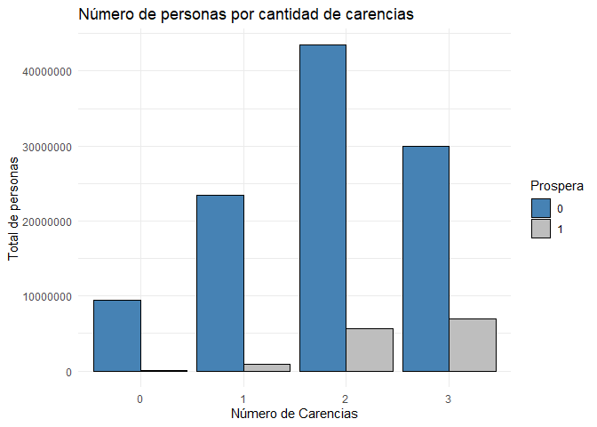

```r
#La variable preocupación_comida indica si el individuo ha tenido está preocupación (1 sí y 0 no)
#La variable informal indica si el individuo trabaja en el sector informal (1 sí y 0 no)
#La variable menor_secundaria indica si el individuo tiene menor educación secundaria (1 sí y 0 no)
#La variable prospera indica si el individuo está en prospera o no (1 sí y 0 no)
base_grafica<-base%>%
  mutate(preocupacion_comida=as.numeric(preocupacion_comida),
    total_carencias=informal+preocupacion_comida+menor_secundaria)

base_grafica_2<-base_grafica%>%
  group_by(total_carencias, prospera)%>%
  summarize(total=sum(factor,na.rm=T))%>%
  filter(!is.na(total_carencias))%>%
  ungroup()


p<-ggplot(data=base_grafica_2, aes(x=as.factor(total_carencias), y=total, fill=as.factor(prospera))) +
geom_bar(stat="identity", color="black", position=position_dodge())+
  theme_minimal()+
  scale_fill_manual("Prospera",values=c("steelblue", "grey"))+
  labs(title = "Número de personas por cantidad de carencias")+
  xlab(label = "Número de Carencias")+
  ylab("Total de personas")

p
```

Uno de los grupos en situación de vulnerabilidad en México son aquellos que pertenecen a etnias indígenas, en particular las mujeres en este grupo. Por lo tanto, es relevante analizar el acceso al programa Prospera de los diferentes grupos poblacionales: por sexo y por su autoadscripción a una etnia en particular.

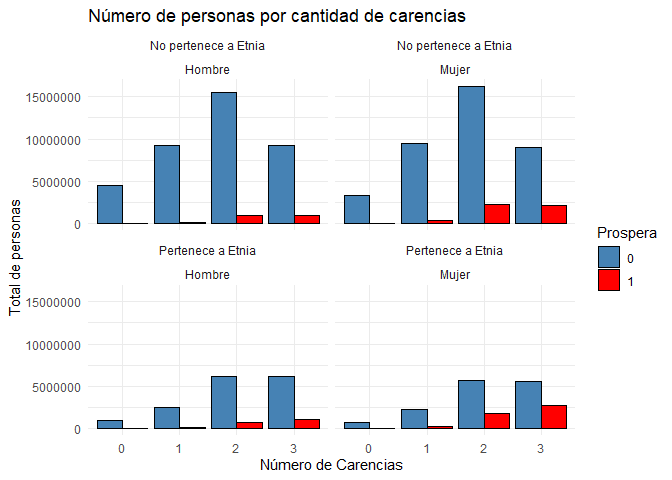

```r
#Gráfica para ver número de personas por sexo, etnia, carencias y beneficiarios del programa.
base_grafica_2<-base_grafica %>%
  group_by(total_carencias, prospera, etnia, sexo)%>%
  summarize(total=sum(factor,na.rm=T))%>%
  filter(!is.na(total_carencias))%>%
  ungroup()

base_grafica_2<-base_grafica_2 %>%
  mutate(etnia2=ifelse(etnia==1, "Pertenece a Etnia","No pertenece a Etnia"),
         sexo2=ifelse(sexo==1, "Hombre", "Mujer"))

p2<-ggplot(data=base_grafica_2, aes(x=as.factor(total_carencias), y=total, fill=as.factor(prospera))) +
geom_bar(stat="identity", color="black", position=position_dodge())+
  theme_minimal()+
  scale_fill_manual("Prospera",values=c("steelblue", "red"))+
  labs(title = "Número de personas por cantidad de carencias")+
  xlab(label = "Número de Carencias")+
  ylab("Total de personas")+
  facet_wrap(~etnia2+sexo2)

p2
```

Podemos ver que la mayoría de la población no pertenece a un grupo étnico. Sin embargo, en términos proporcionales, las mujeres tienen un mayor acceso al programa prospera que los hombres, en particular para las personas con 2 o 3 carencias. Además, son las mujeres que pertenecen a una etnia las que en términos proporcionales tienen un mayor acceso al programa.

Es importante corroborar que las personas beneficiarias del programa también son las que tienen menores ingresos. Para esto analizamos la distribución del ingreso entre los beneficiarios del programa prospera y los no beneficiarios. Podemos notar que efectivamente la mayoría de los individuos inscritos en el programa tienen un ingreso bajo, sin embargo, aún hay una cantidad importante con bajos ingresos y sin acceso al programa.

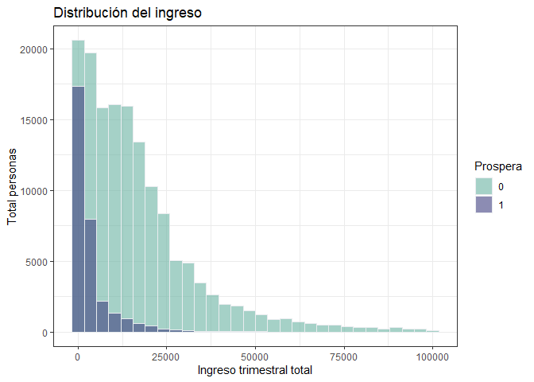

```r
p <- base %>%
  filter(ing_tri_tot<100000) %>%
  ggplot( aes(x=ing_tri_tot, fill=as.factor(prospera))) +
    geom_histogram( color="#e9ecef", alpha=0.6, position = 'identity') +
    scale_fill_manual("Prospera",values=c("#69b3a2", "#404080")) +
    labs(fill="")+
  theme_bw()+
  labs(title = "Distribución del ingreso")+
  xlab("Ingreso trimestral total")+
  ylab("Total personas")
p
```

## Implementación del Causal Machine Learning

Con respecto a los fundamentos del aprendizaje estadístico causal, el interés primordial de la evaluación de impacto que planteamos aquí, busca identificar el efecto que tiene PROSPERA en las 3 variables de respuesta propuestas. En este sentido, nuestro planteamiento se resume en:
$$\begin{align*}
Y_{i} = X_{i}\beta + \tau PROSPERA_{i} + \epsilon
\end{align*}$$
Donde:

- $Y_{i}$ es:
  1. Si en alguna ocasión el hogar se preocupó por que faltara comida ($CarenciaComida_{i}$);
  2. La probabilidad de que los miembros del hogar tuvieran un empleo informal ($Informal_{i}$);
  3. La probabilidad de que los integrantes terminaran secundaria ($Secundaria_{i}$)
- $X$ es una matriz de tamaño (192,049 x 904) que incluye todas las variables obtenidas de ENIGH que identifica características físicas de la vivienda, de activos en el hogar, de ingresos, pertenencia a sistemas de salud, particularidades sociodemográficas y relación con la familia.
- $PROSPERA_{i}$ es la variable que identifica si el individuo es beneficiario del programa gubernamental, ya sea de manera directa o a través de la relación con algún miembro del hogar. Dada la construcción de la variable está es dicotómica.

El parámetro de interés en todo el planteamiento es $\tau$, que identifica el impacto del tratamiento en cada una de las variables dependientes. De manera aún más específica, buscamos llegar econométricamente a:
$$\begin{align*}
\tau_{i}=\frac{\partial Y_{i}}{\partial T_{i}}
\end{align*}$$
Tomando en cuenta que la unidad de observación de nuestro estudio ($i$) son individuos por lo que contamos con 192,049 representativos de la población mexicana.

## Preparación de matrices

Después de juntar toda la información, inspeccionamos detalladamente la manera en que estaban codificadas las respuestas lo cual está íntimamente relacionado con el manejo de los valores faltantes. La determinación de imputar o eliminar variables y observaciones la realizamos basados en la lógica y la intención con la que se diseñaron los cuestionarios. De esta manera, el uso de los diccionarios fue una herramienta esencial y explotada en todo momento. Contar con toda la información de cada una de las preguntas, tuvo la consecuencia de ser un arma de doble filo: muchas variables para explorar, pero muchos errores de codificación producto natural de la manera en que se ejecutan estos programas en campo. [^1]

Para asignar entrenamiento y validación utilizamos la función `treatment_assign` de la librería RCT. Esta función crea una variable dicotómica que indica si la observación es de la base de entremiento o de validación. La asignación aleatoria es robusta y por estrato, aunque en nuestro caso no nos interesa utilizar ningún estrato. Utilizamos una división 80/20 como es usual. La función nos devuelve un vector con las asignaciones por observación, que luego pegamos a la base original.

# Modelos

## Double Debiased Machine Learning

El método DDML se motiva así:
$$y_i=\tau T_i+m(X_i)+\epsilon_i$$
$$T_i=g(X_i)+u_i$$
donde m y g son funciones desconocidas de todas las variables que podemos estimar por nuestro método favorito de Machine Learning. En particular, decidimos utilizar una estimación Cross Validated Lasso. La parte Lasso nos permite identificar las relaciones de baja linealidad entre las covariables. Cross validated significa que partimos nuestra base de entrenamiento en K partes iguales, para posteriormente:

- estimar g en K-1 partes
- utilizar la K-ésima como si fuera una base de “validación” del entrenamiento i.e. predecir con la estimación anterior los valores de la variable de interés $\hat{y_{i\in K}}=g(X_{i\in K})$ y ver su diferencia respecto a los valores reales $V^y_{i\in K}=y_{i\in K}-\hat{y_{i\in K}}$
- hacer lo mismo para m y obtenemos $V^T_{i\in K}=T_{i\in K}-\hat{T_{i\in K}}$

Ya logramos aislar cualquier impacto de variables relevantes X tanto en Y como en T. Los residuales $V^y_{i\in K},V^T_{i\in K}$ son independientes de cualquier efecto de X. Es decir, la relación $\tau$ que obtengamos de la regresión
$$V^y_{i\in K}=\alpha+\tau V^T_{i\in K}+\phi_i$$
captura todo el efecto directo del tratamiento en la variable de interés sin intermediación de alguna otra covariable. Ergo, es una relación causal.

Al utilizar LASSO para estimar la relación de las covariables con T y Y, logramos reducir los errores al mínimo. La función LASSO por sí misma encuentra (casi) todas las combinaciones que se nos puedan ocurrir que afectan a Y y T. Además, solo hace falta que una de las estimaciones sea perfecta (es decir, elimine todo el efecto de las covariables en los residuales) para que el sesgo de selección sea cero. Logramos una estimación doblemente robusta.

## Análisis de Impacto con DDML

```r
colnames(data_entrenamiento)[grepl(" ", colnames(data_entrenamiento))] <- str_replace(colnames(data)[grepl(" ", colnames(data_entrenamiento))], " ", "")
colnames(data_validacion)[grepl(" ", colnames(data_validacion))] <- str_replace(colnames(data)[grepl(" ", colnames(data_validacion))], " ", "")

#DD LASSO

#Partimos base en k=5 partes iguales
lasso_treat <- vector(mode="list", length=5)
lasso_monto <- vector(mode="list", length=5)

data_entrenamiento <-data_entrenamiento%>%
  arrange(prospera)

k<-treatment_assign(data = data_entrenamiento, share_control = 0.2, n_t = 4,
                    strata_varlist = "prospera",missfits = "global",
                    seed = 1900, key ="prospera")$data
k <- k%>%
  mutate(k = treat+1) %>%
  ungroup()

data_entrenamiento<-bind_cols(data_entrenamiento, k %>% select(k))
k<-k$k

#----------------------------
#DDML para preocupación comida

info_ret<-data_entrenamiento$preocupacion_comida
treat<-data_entrenamiento$prospera

X<-data_entrenamiento %>%
  select(-preocupacion_comida, -prospera,-k, -tratamiento)


modelo<-map_dfr(1:5,
                function(a) {

                  treat_fit <-gamlr(x = X[k!=a, , drop= F],
                                    y = treat[k!=a], family="binomial")
                  treat_hat<-as.numeric(predict(treat_fit,
                                                newdata = X[k==a, , drop= F],
                                                type = "response"))
                  lasso_treat[[a]] <<- treat_fit

                  info_treat <- gamlr(x = X[k!=a, , drop= F],
                                     y =  info_ret[k!=a])
                  info_hat <- as.numeric(predict(info_treat,newdata = X[k==a, ,
                                                                        drop= F],
                                                  type ="response"))
                  lasso_monto[[a]] <<- info_treat

                  treat_resid <- treat[k==a]-treat_hat
                  resid_y <- info_ret[k==a]-info_hat

                  fits<-bind_cols("treat_hat" = treat_hat,
                                  "info_hat"= info_hat,
                                  "resid_treat" = treat_resid,
                                  "resid_y" = resid_y)
                })
#Corremos modelo lineal
mod1_res <- lm(resid_y~resid_treat,data = modelo)

#Coeficientes de los 5 modelos
coefs_treat<-lapply(lasso_treat, function(x) as.data.frame(as.matrix(coef(x))))
coefs_treat<-lapply(coefs_treat, function(x) x %>% filter(.!=0))

coefs_mont<-lapply(lasso_monto, function(x) as.data.frame(as.matrix(coef(x))))
coefs_mont<-lapply(coefs_mont, function(x) x %>% filter(.!=0))

for(i in 1:5){
  names(coefs_treat[[i]]) <- "Coeficientes"
  names(coefs_mont[[i]]) <- "Coeficientes"

  setDT(coefs_treat[[i]], keep.rownames = "Nombres")[]
  setDT(coefs_treat[[i]], keep.rownames = "Nombres")[]

}

#Guardamos variables relevantes para preocupación comida.

coefs_treat_comida<-coefs_treat
coefs_y_comida<-coefs_mont

#-------------------------
#DDML para menor_sec

info_ret<-data_entrenamiento$menor_secundaria
treat<-data_entrenamiento$prospera

X<-data_entrenamiento %>%
  select(-menor_secundaria, -prospera,-k, -tratamiento)


modelo<-map_dfr(1:5,
                function(a) {

                  treat_fit <-gamlr(x = X[k!=a, , drop= F],
                                    y = treat[k!=a], family="binomial")
                  treat_hat<-as.numeric(predict(treat_fit,
                                                newdata = X[k==a, , drop= F],
                                                type = "response"))
                  lasso_treat[[a]] <<- treat_fit

                  info_treat <- gamlr(x = X[k!=a, , drop= F],
                                      y =  info_ret[k!=a])
                  info_hat <- as.numeric(predict(info_treat,newdata = X[k==a, ,
                                                                        drop= F],
                                                 type ="response"))
                  lasso_monto[[a]] <<- info_treat

                  treat_resid <- treat[k==a]-treat_hat
                  resid_y <- info_ret[k==a]-info_hat

                  fits<-bind_cols("treat_hat" = treat_hat,
                                  "info_hat"= info_hat,
                                  "resid_treat" = treat_resid,
                                  "resid_y" = resid_y)
                })


#Corremos modelo lineal
mod2_res <- lm(resid_y~resid_treat,data = modelo)


#Coeficientes de los 5 modelos
coefs_treat<-lapply(lasso_treat, function(x) as.data.frame(as.matrix(coef(x))))
coefs_treat<-lapply(coefs_treat, function(x) x %>% filter(.!=0))

coefs_mont<-lapply(lasso_monto, function(x) as.data.frame(as.matrix(coef(x))))
coefs_mont<-lapply(coefs_mont, function(x) x %>% filter(.!=0))

for(i in 1:5){
  names(coefs_treat[[i]]) <- "Coeficientes"
  names(coefs_mont[[i]]) <- "Coeficientes"

  setDT(coefs_treat[[i]], keep.rownames = "Nombres")[]
  setDT(coefs_treat[[i]], keep.rownames = "Nombres")[]

}

#Guardamos variables relevantes para menor_sec.

coefs_treat_menor_sec<-coefs_treat
coefs_y_menor_sec<-coefs_mont


#-------------------------
#DDML para informalidad

info_ret<-data_entrenamiento$informal
treat<-data_entrenamiento$prospera

X<-data_entrenamiento %>%
  select(-informal, -prospera,-k, -tratamiento)


modelo<-map_dfr(1:5,
                function(a) {

                  treat_fit <-gamlr(x = X[k!=a, , drop= F],
                                    y = treat[k!=a], family="binomial")
                  treat_hat<-as.numeric(predict(treat_fit,
                                                newdata = X[k==a, , drop= F],
                                                type = "response"))
                  lasso_treat[[a]] <<- treat_fit

                  info_treat <- gamlr(x = X[k!=a, , drop= F],
                                      y =  info_ret[k!=a])
                  info_hat <- as.numeric(predict(info_treat,newdata = X[k==a, ,
                                                                        drop= F],
                                                 type ="response"))
                  lasso_monto[[a]] <<- info_treat

                  treat_resid <- treat[k==a]-treat_hat
                  resid_y <- info_ret[k==a]-info_hat

                  fits<-bind_cols("treat_hat" = treat_hat,
                                  "info_hat"= info_hat,
                                  "resid_treat" = treat_resid,
                                  "resid_y" = resid_y)
                })


#Corremos modelo lineal
mod3_res <- lm(resid_y~resid_treat,data = modelo)



#Coeficientes de los 5 modelos
coefs_treat<-lapply(lasso_treat, function(x) as.data.frame(as.matrix(coef(x))))
coefs_treat<-lapply(coefs_treat, function(x) x %>% filter(.!=0))

coefs_mont<-lapply(lasso_monto, function(x) as.data.frame(as.matrix(coef(x))))
coefs_mont<-lapply(coefs_mont, function(x) x %>% filter(.!=0))

for(i in 1:5){
  names(coefs_treat[[i]]) <- "Coeficientes"
  names(coefs_mont[[i]]) <- "Coeficientes"

  setDT(coefs_treat[[i]], keep.rownames = "Nombres")[]
  setDT(coefs_treat[[i]], keep.rownames = "Nombres")[]

}

#Guardamos variables relevantes para informalidad.

coefs_treat_informalidad<-coefs_treat
coefs_y_informalidad<-coefs_mont
```

Con la implementación de este algoritmo podemos encontrar el $\tau$ (i.e. el ATE) de Prospera sobre las tres distintas variables de objetivo definidas al inicio de nuestro análisis.

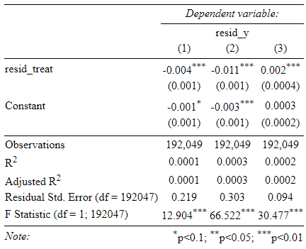

Una vez estimados los tres modelos DDML LASSSO para las 3 variables de interés, corrimos la regresión lineal entre los residuales de las variables dependientes sobre los residuales de las estimaciones de tratamiento. Dado que construimos los residuales de la variable dependiente y de tratamiento que no son explicadas por las X´s, esta estimación nos arroja una relación causal y doblemente robusta. Los coeficientes de los residuales del tratamiento nos arrojarán el ATE estimado por los modelos. En los resultados para las variables son los siguientes:

## Variables Relevantes para cada especificación

```r
#Variables relevantes para cada carencia:

#Alimentación:
union<-inner_join(coefs_treat_comida[[1]],coefs_treat_comida[[2]], by="Nombres")


for(i in 3:4){
  union<-inner_join(coefs_treat_comida[[i]],union, by="Nombres")
}


union<-union %>%
  drop_na()

union<-cbind(union,promedio=rowMeans(union[,2:5],na.rm=T))

union_alimentos<-union%>%
  select(Nombres, promedio)

rm(union)


#Informalidad:
union<-inner_join(coefs_treat_informalidad[[1]],coefs_treat_informalidad[[2]], by="Nombres")


for(i in 3:4){
  union<-inner_join(coefs_treat_informalidad[[i]],union, by="Nombres")
}


union<-union %>%
  drop_na()

union<-cbind(union,promedio=rowMeans(union[,2:5],na.rm=T))

union_alimentos<-union%>%
  select(Nombres, promedio)

rm(union)


#Menor Secundaria:
union<-inner_join(coefs_treat_menor_sec[[1]],coefs_treat_menor_sec[[2]], by="Nombres")


for(i in 3:4){
  union<-inner_join(coefs_treat_menor_sec[[i]],union, by="Nombres")
}


union<-union %>%
  drop_na()

union<-cbind(union,promedio=rowMeans(union[,2:5],na.rm=T))

union_alimentos<-union%>%
  select(Nombres, promedio)

rm(union)
```

## Ahora las variables relevantes para **todas** las especificaciones

```r
union_todas<-inner_join(union_alimentos,union_informalidad, by="Nombres")
union_todas<-inner_join(union_menor_sec,union_todas, by="Nombres")

union_todas<-union_todas %>%
  filter(abs(promedio)>0.001, Nombres!="intercept") %>%
  arrange(-abs(promedio))
union_todas <- union_todas %>% slice(3:86)
```

De los distintos modelos LASSO estimados, guardamos las variables que eran relevantes para explicar el efecto del programa Prospera sobre las variables dependientes de interés. Notamos que muchas variables de interés se repetían, tanto entre distintos modelos que explicaban la relación para la misma variable dependiente, como entre modelos estimados para distintas variables dependientes. Identificamos las variables relevantes que se repetían para todos los distintos modelos y para todas las distintas variables de interés. Luego promediamos el valor de los coeficientes estimados, para cada una de estas variables. Ordenando de mayor a menor las variables que resultaron más relevantes para estimar el efecto de tratamiento, es decir, que tenían un promedio de los coeficientes más grandes en valor absoluto, obtuvimos la siguiente lista:

```r
kable(union_todas, align = c("c", "c", "c"), caption="Variables relevantes para los beneficiarios del Programa Prospera bajo todas las carencias.",digits=3, col.names = linebreak(c("Variable", "Prom. Alimentos", "Prom. Informalidad","Prom. Menor Secundaria")))%>%
  kable_classic(full_width = F, html_font = "Cambria") %>%
  footnote(general = "Elaboración propia con datos de ENIGH (2018).",threeparttable = T, footnote_as_chunk = T) %>%
  row_spec(0, bold = T)
```

Variables relevantes para los beneficiarios del Programa Prospera bajo todas las carencias.

| Variable | Prom. Alimentos | Prom. Informalidad | Prom. Menor Secundaria |
| --- | --- | --- | --- |
| inst_5_0 | -6.158 | -6.158 | -6.169 |
| forma_b_1 | 3.102 | 3.102 | 3.126 |
| ing_tri_tot_missing | -2.893 | -2.893 | -2.897 |
| segpop_1 | 1.137 | 1.137 | 1.132 |
| sexo_1 | -0.794 | -0.794 | -0.802 |
| forma_b_3 | 0.684 | 0.684 | 0.701 |
| residencia_12 | 0.679 | 0.679 | 0.693 |
| tiene_b_1 | 0.604 | 0.604 | 0.582 |
| peso_0 | -0.509 | -0.509 | -0.514 |
| residencia_14 | 0.472 | 0.472 | 0.470 |
| recib_tvd_1 | 0.452 | 0.452 | 0.452 |
| tipoesc_1 | 0.441 | 0.441 | 0.387 |
| antec_esc_missing | 0.379 | 0.379 | 0.176 |
| residencia_18 | 0.341 | 0.341 | 0.344 |
| residencia_9 | -0.335 | -0.335 | -0.327 |
| est_socio | -0.317 | -0.317 | -0.315 |
| antec_esc_3 | -0.298 | -0.298 | -0.346 |
| nivel_7 | 0.270 | 0.270 | 0.259 |
| tot_hom_0 | -0.241 | -0.241 | -0.241 |
| tot_resid_2 | -0.236 | -0.236 | -0.237 |
| nivel_12 | -0.233 | -0.233 | -0.099 |
| recib_tvd_2 | -0.230 | -0.230 | -0.230 |
| hijos_sob | 0.221 | 0.221 | 0.218 |
| medtrab_7_0 | 0.196 | 0.196 | 0.197 |
| tam_loc_3 | 0.187 | 0.187 | 0.192 |
| act_pnea2_3 | -0.186 | -0.186 | -0.175 |
| segvol_3 | 0.184 | 0.184 | 0.176 |
| mat_pisos_3 | -0.182 | -0.182 | -0.179 |
| telefono_1 | -0.164 | -0.164 | -0.160 |
| edo_conyug_5 | -0.163 | -0.163 | -0.162 |

[output cut: 56 more lines]

Note: Elaboración propia con datos de ENIGH (2018).

Estas variables nos arrojan algunos resultados interesantes. Por un lado, la variable `ing_tri_tot_missing` que señala a las personas que no reportaron su ingreso trimestral total, resulta importante para explicar la relación con Prospera. Puede ser que estas personas tengan muy bajos ingresos trimestrales o no quisieran compartir esa información, lo que podría ser tanto por miedo para mantener los beneficios del programa, por miedo a ser robados o por vergüenza de tener un ingreso bajo. Otra variable que resultó relevante, que ya habíamos explorado al inicio de esta investigación, es la variable `sexo_1` (dummy que indica si el individuo es hombre), y tiene una relación negativa con el tratamiento. Es decir, los hombres tienen en promedio una menor probabilidad de obtener el programa. Una variable que resultó sorprendente que fuera relevante es `residencia_12`, una variable que indica si el individuo reside en el estado de Guerrero. El hecho de vivir en esta entidad se relaciona positivamente con el hecho de recibir los beneficios del programa, lo que es razonable por los elevados niveles de pobreza que tiene esa entidad. Esto es consistente porque la variable `residencia_9`, que indica si la persona vive en el Distrito Federal, tiene una relación negativa con el tratamiento. Otra relación curiosa es que la variable `recib_tvd_1`, que indica que el individuo recibió televisor digital de parte del Gobierno Federal, tiene una relación positiva y elevada con el programa, ya que puede ser el caso que las personas que recibieron televisor fueron las más vulnerables. Finalmente, también es consistente que las personas que respondieron que no tenían servicio médico de parte de su trabajo (`medtrab_7`) tienen una relación positiva con la recepción del programa.

# Implementación con Causal Forest

¿Qué sucede si queremos estimar relaciones altamente no lineales? una alternativa son los Causal Trees. Vamos dividiendo la muestra, partiendo de las variables más significativas. Básicamente la mecánica es parecida al DDML: partes tus datos en un conjunto para entrenar y otro para estimar, hacemos algo similar a “cross validation” y predecimos en la base para estimar.

Nuestro objetivo es que en cada nueva rama logremos un mayor poder explicativo, pero que dentro de cada rama las poblaciones sean balanceadas. Eliminamos las ramas que sean redundantes, y estimamos el efecto del árbol con la base de estimación.

Un causal forest es estimar distintos árboles partiendo de selecciones aleatorias de la muestra, y nos quedamos con el efecto promedio.

```r
# Modelo 1
# Vector con el outcome
Y <-  data_entrenamiento %>%
  pull(informal)

# Matriz con las variables explicativas
# X <- sparse.model.matrix(~.+0,
#                          data = data_entrenamiento %>%
#                            select(-informal,
#                                   -preocupacion_comida, -menor_secundaria,
#                                   -prospera))
X <- data_entrenamiento %>%
  select(-informal,
         -preocupacion_comida, -menor_secundaria,
         -prospera, -tratamiento) %>%
  as.matrix()

# Vector con los tratamientos
W <- data_entrenamiento %>%
  pull(prospera)

# Corremos el causal forest
forest <- causal_forest(X = X, Y = Y, W = W, num.trees = 750)

# Guardar el causal forest para no tener que volverlo a correr
saveRDS(forest, "./causal_forest_1.rds")

# Modelo 2
# Vector con el outcome
Y <-  data_entrenamiento %>%
  pull(preocupacion_comida)

# Corremos el causal forest
forest <- causal_forest(X = X, Y = Y, W = W, num.trees = 750)

# Guardar el causal forest para no tener que volverlo a correr
saveRDS(forest, "./causal_forest_2.rds")

# Modelo 3
# Vector con el outcome
Y <-  data_entrenamiento %>%
  pull(menor_secundaria)

# Corremos el causal forest
forest <- causal_forest(X = X, Y = Y, W = W, num.trees = 750)

# Guardar el causal forest para no tener que volverlo a correr
saveRDS(forest, "./causal_forest_3.rds")

######### Analisis de predicciones #############
# Leer modelos de Causal forest
forest_1 <- readRDS("causal_forest_1.rds")
forest_2 <- readRDS("causal_forest_2.rds")
forest_3 <- readRDS("causal_forest_3.rds")


ate1 <- average_treatment_effect(forest_1,
                                target.sample = "all", method = "AIPW")

ate2 <- average_treatment_effect(forest_2,
                                 target.sample = "all", method = "AIPW")

ate3 <- average_treatment_effect(forest_3,
                                 target.sample = "all", method = "AIPW")

X_val <- data_validacion %>%
  select(-informal,
         -preocupacion_comida, -menor_secundaria,
         -prospera, -tratamiento) %>%
  as.matrix()

data_validacion$ate1 <- predict(forest_1, X_val)$predictions
data_validacion$ate2 <- predict(forest_2, X_val)$predictions
data_validacion$ate3 <- predict(forest_3, X_val)$predictions
```

## Evaluación de impacto con Causal Forest

# Tabla y Gráfica para Informalidad

Variables relevantes para los beneficiarios del Programa Prospera

| Variable | Bottom 20% | Top 20% | p value |
| --- | --- | --- | --- |
| edad | 35.8851 | 40.5278 | 0.0000 |
| est_alim | 3793.7749 | 3504.0453 | 0.0000 |
| gradoaprob_3 | 0.4841 | 0.4884 | 0.5440 |
| hijos_sob | 0.5723 | 0.8854 | 0.0000 |
| hijos_viv | 0.5949 | 0.9328 | 0.0000 |
| hor_4 | 5.0084 | 5.7088 | 0.0001 |
| hor_6 | 8.3236 | 9.4175 | 0.0000 |
| sexo_1 | 0.6197 | 0.5990 | 0.0034 |
| sexo_2 | 0.3803 | 0.4010 | 0.0034 |
| ss_aa | 5.3943 | 6.4802 | 0.0000 |

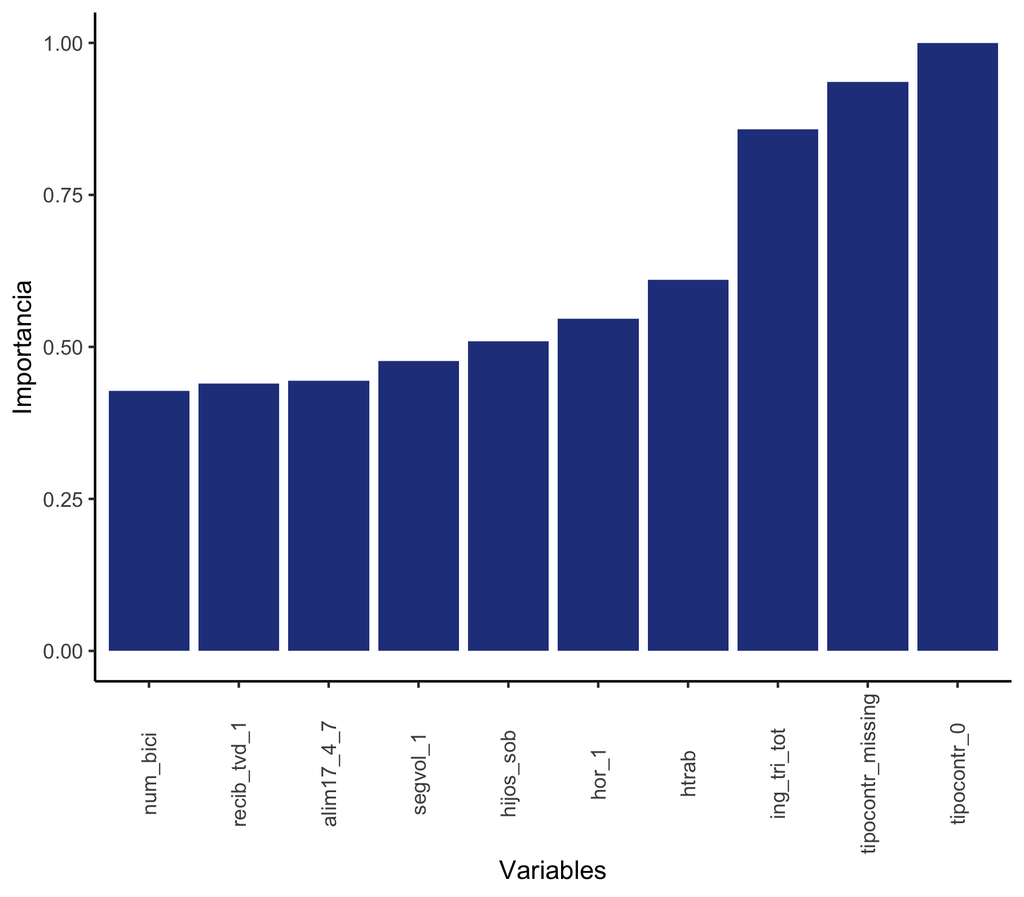

# Tabla y Gráfica para Alimentación

Ahora, nos enfocaremos en el impacto del programa Prospera sobre las limitaciones alimenticias que enfrentan los hogares. De igual forma que para la variable de informalidad, la edad es importante, en este caso se debería de beneficiar a los que tienen una menor edad. También se debe de apoyar, para sacar el máximo beneficio del programa, a aquellos que tienen una gran cantidad de hijos y un grado menor a tercero de primaria.

Variables relevantes para los beneficiarios del Programa Prospera

| Variable | Bottom 20% | Top 20% | p value |
| --- | --- | --- | --- |
| edad | 35.1850 | 33.9171 | 0.0000 |
| est_alim | 2986.3258 | 3382.1760 | 0.0000 |
| gradoaprob_3 | 0.3764 | 0.4633 | 0.0000 |
| hijos_sob | 0.8949 | 1.0454 | 0.0000 |
| hijos_viv | 0.9707 | 1.1307 | 0.0000 |
| hor_4 | 4.1402 | 6.8797 | 0.0000 |
| hor_6 | 9.4756 | 11.0780 | 0.0000 |
| sexo_1 | 0.5176 | 0.4737 | 0.0000 |
| sexo_2 | 0.4824 | 0.5263 | 0.0000 |
| ss_aa | 3.0613 | 3.0520 | 0.9295 |

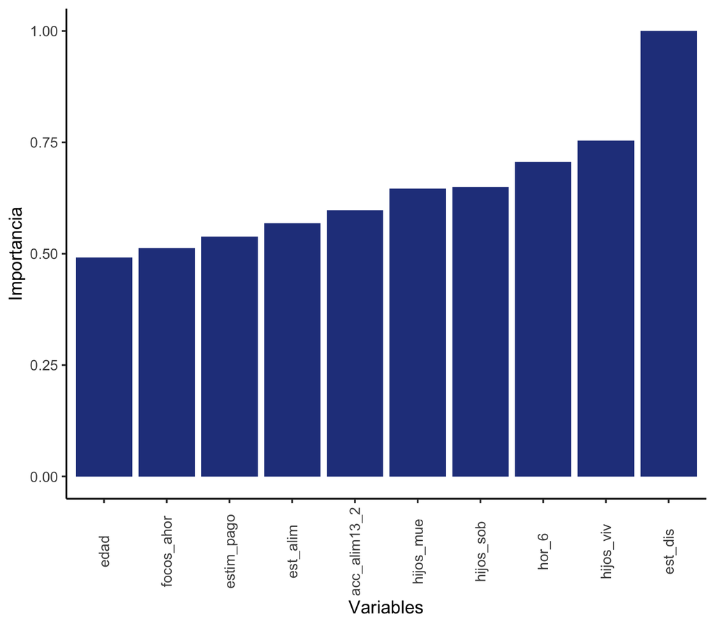

# Tabla y Gráfica para Educación - Secundaria

Por último, también se analizó el impacto del programa Prospera sobre el nivel educativo, en particular si el individuo terminó al menos la secundaria. Lo que encontramos es que Prospera tiene un impacto negativo contrario a lo que se esperaría, pues los beneficiados de Prospera tuvieron una menor probabilidad de terminar la secundaria según las estimaciones del modelo. Esto puede ser a causa de que los individuos fueron beneficiados cuando ya eran adultos y por lo tanto no pudieron cambiar su nivel educativo.

Variables relevantes para los beneficiarios del Programa Prospera

| Variable | Bottom 20% | Top 20% | p value |
| --- | --- | --- | --- |
| edad | 38.7461 | 23.1794 | 0 |
| est_alim | 3721.0645 | 3375.1398 | 0 |
| gradoaprob_3 | 0.6647 | 0.3600 | 0 |
| hijos_sob | 1.6322 | 0.0595 | 0 |
| hijos_viv | 1.6792 | 0.0689 | 0 |
| hor_4 | 13.6978 | 1.7174 | 0 |
| hor_6 | 20.0442 | 3.5934 | 0 |
| sexo_1 | 0.2289 | 0.6851 | 0 |
| sexo_2 | 0.7711 | 0.3149 | 0 |
| ss_aa | 6.0284 | 1.3974 | 0 |

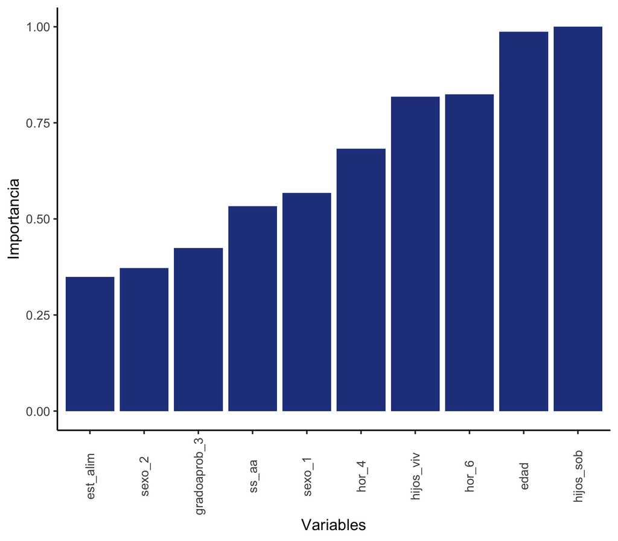

```r
data_validacion <- data_validacion %>%
  mutate(decil_informal = ntile(ate1, 10), decil_alim = ntile(ate2, 10),
         decil_secu = ntile(ate3, 10))

itt_ate1 <- impact_eval(data_validacion,
                        endogenous_vars = "informal",
                        treatment = "prospera",
                        heterogenous_vars = "decil_informal")$informal_decil_informal

itt_ate1 <- itt_ate1 %>%
  dplyr::filter(term != "(Intercept)") %>%
  mutate(decil_informal = factor(decil_informal,
                                 levels = c("1","2","3","4",
                                                      "5","6","7","8","9","10")))

decils_ate1 <- data_validacion %>%
  group_by(decil_informal) %>%
  summarise(media_informal = mean(ate1)) %>%
  mutate(decil_informal = factor(decil_informal, levels = c("1","2","3","4",
                                                    "5","6","7","8","9","10")))

decils_ate1 <- decils_ate1 %>%
  left_join(itt_ate1 %>% select(decil_informal, estimate),
            by = "decil_informal")

decils_ate1 <- decils_ate1 %>%
  pivot_longer(cols = c(media_informal, estimate))
ggplot(decils_ate1, aes(x = decil_informal, y = value, color = name)) +
  geom_line() +
  geom_point(shape = 21, size = 2) +
  theme_bw()
```

Dados los resultados mencionados en anteriores párrafos, recomendamos que el programa, dada una cantidad fija de apoyo, debería de empezar a dar el apoyo a hogares que tienen individuos con una edad alta (aproximadamente de 40 años), que tiene un gasto alimenticio menor a los $3500 pesos, y que tengan un número alto de hijos o dependientes económicos.

# Distribución del CATE - Causal Forest

## Distribución CATE - Informalidad

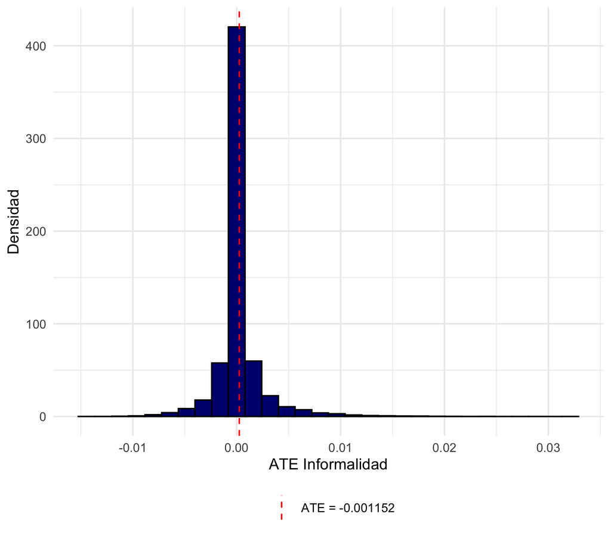

## Distribución CATE - Alimentación

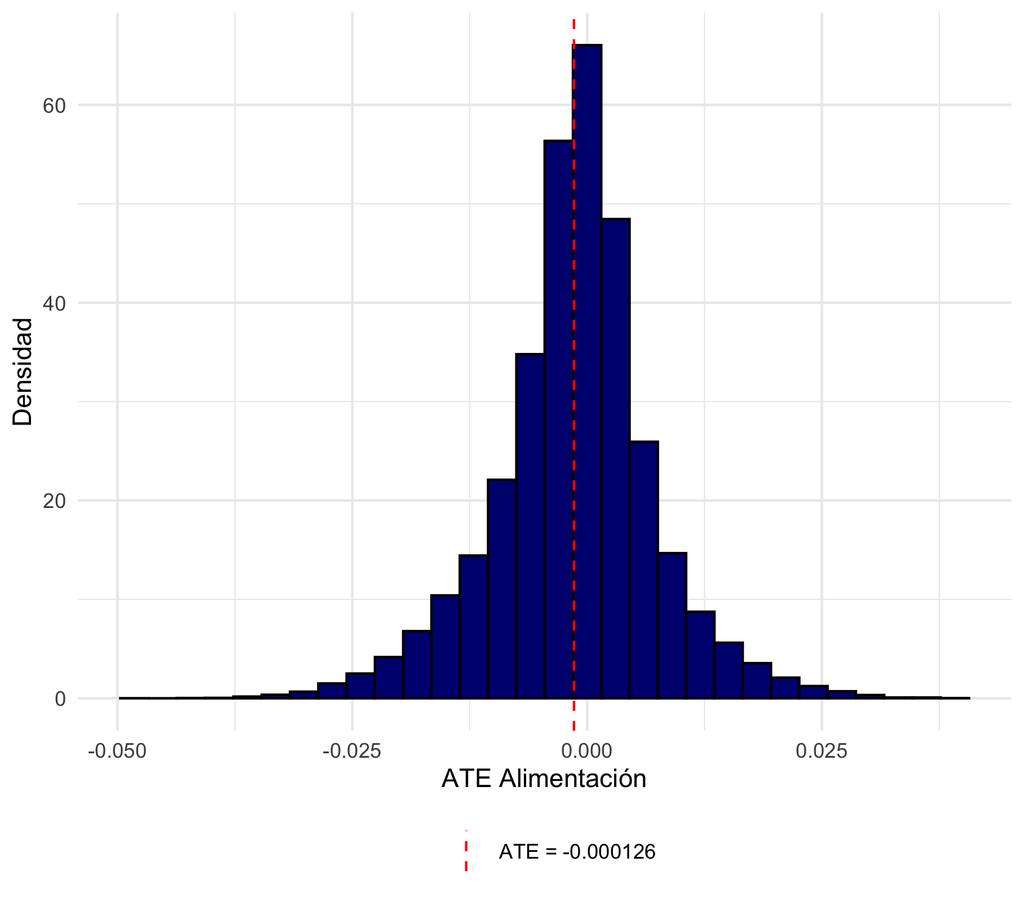

## Distribución CATE - Educación

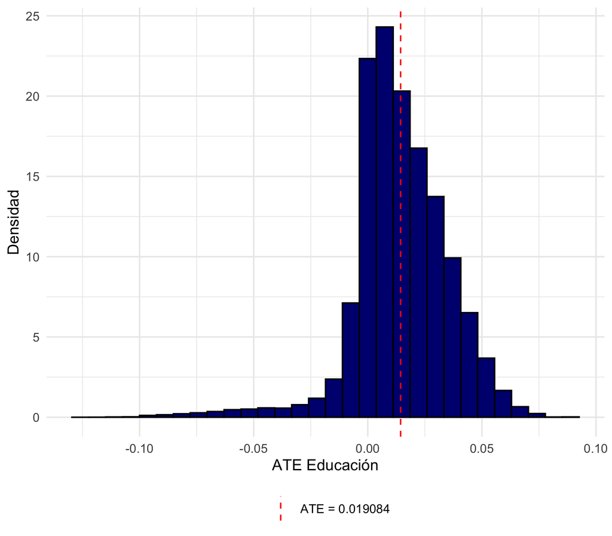

# Conclusión

La evaluación de impacto del programa Prospera comenzó por analizar estadísticas descriptivas. De estas estadísticas se puede observar que existe un gran porcentaje de la población con al menos una de las carencias analizadas (alimenticias, educativas y laborales). De igual forma, se puede observar que el programa Prospera beneficia a aquellos individuos con más carencias, en particular a los grupos vulnerables (las mujeres y grupos indígenas).

El siguiente paso para evaluar el programa fue utilizar dos modelos de causal machine learning. El primer modelo que se usó fue un modelo Double Debiased Machine Learning, de este modelo se obtuvo el Average Treatment Effect para las tres variables de interés relevantes y también se obtuvieron las variables que los modelos Lasso identificaron como determinantes para explicar el tratamiento, es decir, a quienes recibieron los beneficios del programa Prospera.

El segundo modelo que se utilizó fue un Causal Forest. De este modelo se encontró que se debe dar prioridad a aquellos hogares que tienen un gasto en alimentación bajo, que tienen un alto número de dependientes económicos y con edades promedio altas.

# Anexo - Validación del Modelo Causal Forest

Dado que no existe un ATE observado, se tiene que realizar la siguiente estrategia: 1) Dividir por deciles con respecto al ATE predicho por el Causal Forest, 2) Correr una regresión a nivel decil, 3) Sacar el promedio del ATE predicho por el Causal Forest a nivel decil, 4) Comparar si la monotonía en ambas estimaciones es similar. A pesar de seguir todos los pasos recomendados para la validación, los resultados no van en la dirección esperada en algunos casos.

## Probando Monotonía en Informalidad

[figure not shown]

## Probando Monotonía en Alimentación

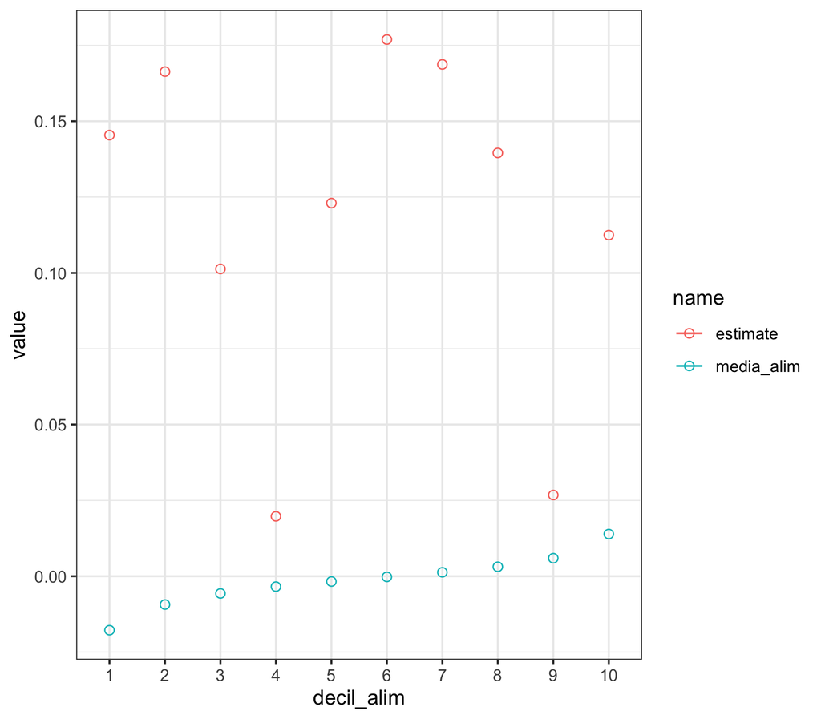

```r
## Para ATE 2
itt_ate2 <- impact_eval(data_validacion,
                        endogenous_vars = "preocupacion_comida",
                        treatment = "prospera",
                        heterogenous_vars = "decil_alim")$preocupacion_comida_decil_alim

itt_ate2 <- itt_ate2 %>%
  dplyr::filter(term != "(Intercept)") %>%
  mutate(decil_alim = factor(decil_alim,
                                 levels = c("1","2","3","4",
                                            "5","6","7","8","9","10")))

decils_ate2 <- data_validacion %>%
  group_by(decil_alim) %>%
  summarise(media_alim = mean(ate2)) %>%
  mutate(decil_alim = factor(decil_alim, levels = c("1","2","3","4",
                                                            "5","6","7","8","9","10")))

decils_ate2 <- decils_ate2 %>%
  left_join(itt_ate2 %>% select(decil_alim, estimate),
            by = "decil_alim")

decils_ate2 <- decils_ate2 %>%
  pivot_longer(cols = c(media_alim, estimate))

ggplot(decils_ate2, aes(x = decil_alim, y = value, color = name)) +
  geom_line() +
  geom_point(shape = 21, size = 2) +
  theme_bw()
```

## Probando Monotonía en Educación

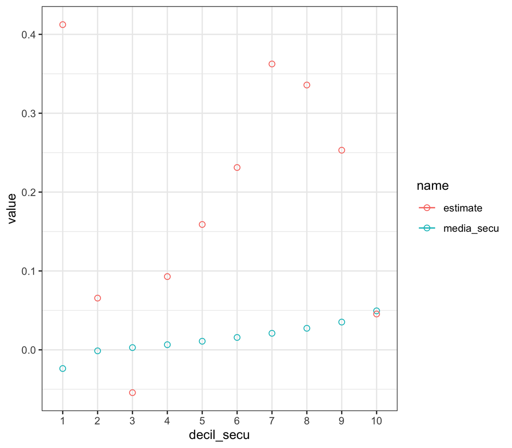

```r
itt_ate3 <- impact_eval(data_validacion,
                        endogenous_vars = "menor_secundaria",
                        treatment = "prospera",
                        heterogenous_vars = "decil_secu")$menor_secundaria_decil_secu

itt_ate3 <- itt_ate3 %>%
  dplyr::filter(term != "(Intercept)") %>%
  mutate(decil_secu = factor(decil_secu,
                             levels = c("1","2","3","4",
                                        "5","6","7","8","9","10")))

decils_ate3 <- data_validacion %>%
  group_by(decil_secu) %>%
  summarise(media_secu = mean(ate3)) %>%
  mutate(decil_secu = factor(decil_secu, levels = c("1","2","3","4",
                                                    "5","6","7","8","9","10")))

decils_ate3 <- decils_ate3 %>%
  left_join(itt_ate3 %>% select(decil_secu, estimate),
            by = "decil_secu")

decils_ate3 <- decils_ate3 %>%
  pivot_longer(cols = c(media_secu, estimate))

ggplot(decils_ate3, aes(x = decil_secu, y = value, color = name)) +
  geom_line() +
  geom_point(shape = 21, size = 2) +
  theme_bw()
```

[^1]: En nuestro código adjunto, en la medida de lo posible, mostramos limpieza de todas las variables que tenían missing values.